# Team 208 Exploratory Data Analysis

Team members:  
Kuan Ling Chen, Daniel Farr, Koushika Ravikumar, Shristi Shivbhagwan Gaur

## Executive Summary

For this project we aim to help Starbucks better understand their customers and their needs throughout the United States. We are using the review scores and sentiment analysis to quantify customer experience and assess reviews and sentiment has changed over time. This analysis should provide us with insights that can be used to provide Starbucks with solutions to improve and/or maintain the satisfaction of their customers.

## Data Sources

We have solely used the review data from Yelp for our analysis thus far.

To prepare our data, we did an inner join of the business and review json files that included all records that had coffee or cafe in their category. This put the total number of records at about 600,000. To make our analysis more feasible given the time and resources we have, we pivoted to focusing on analyzing Starbucks reviews rather than reviews for all coffee shops. Focusing on just Starbucks puts the total record count at around 20,000.

### Import Statements

```python
from google.colab import drive
import pandas as pd
import json

drive.mount('/content/drive')
```

```python
import pandas as pd
import numpy as np
```

```python
!pip install vaderSentiment

from vaderSentiment.vaderSentiment import SentimentIntensityAnalyzer
```

```python
!python -m spacy download en_core_web_lg
```

[output not shown]

### Reading in Data and Data Preparation

```python
coffee_file_path = '/content/drive/MyDrive/Yelp Reviews/merged_df.csv'

coffee_df = pd.read_csv(coffee_file_path)
```

```python
starbucks_df = coffee_df[coffee_df['name'].str.contains('Starbucks', na=False)]
starbucks_df.reset_index(drop=True, inplace=True)
starbucks_df
```

|  | review_id | user_id | business_id | stars_x | useful | funny | cool | text | date | name | ... | state | postal_code | latitude | longitude | stars_y | review_count | is_open | attributes | categories | hours |
| --- | --- | --- | --- | --- | --- | --- | --- | --- | --- | --- | --- | --- | --- | --- | --- | --- | --- | --- | --- | --- | --- |
| 0 | ULzbgT5SPThiMOoo4a_Adw | veBX5roHQLNnQ1rTtNh_gg | aJvxWyQIG5OLfBw3qAe8xA | 2 | 0 | 0 | 0 | Ordered Caramel frappe at Drive thru, BIG MIST... | 2017-12-29 19:38:31 | Starbucks | ... | TN | 37217 | 36.085948 | -86.647493 | 3.0 | 65 | 1 | {'BikeParking': 'False', 'RestaurantsPriceRang... | Restaurants, Coffee & Tea, Food | {'Monday': '5:0-21:0', 'Tuesday': '5:0-21:0', ... |
| 1 | RXqhxbAuPPSNs-oyJJyOgw | zZygOZLNyJX5nDqKrwa4HQ | MjZQqZAmJeMco_Vq-Y9h-g | 4 | 0 | 0 | 0 | Drum-roll please! Review #100 coming right up!... | 2014-02-05 19:38:24 | Starbucks | ... | IN | 46033 | 39.979658 | -86.071156 | 3.0 | 33 | 1 | {'OutdoorSeating': 'True', 'WiFi': "u'free'", ... | Food, Coffee & Tea | {'Monday': '5:30-19:0', 'Tuesday': '5:30-19:0'... |
| 2 | LuMkMBAUV1B-2dm2pqSBWw | 0SpK7eVn5TrpyQKPaohVBw | u7MJKcNdZXYyTeb67vD5jw | 4 | 1 | 0 | 0 | We stopped here for my Chai and Hubby's coffee... | 2017-02-09 04:35:39 | Starbucks | ... | NJ | 08054 | 39.980794 | -74.888500 | 1.5 | 17 | 1 | {'RestaurantsPriceRange2': '2', 'BusinessAccep... | Food, Coffee & Tea | {'Monday': '7:0-19:0', 'Tuesday': '7:0-19:0', ... |
| 3 | Z0Jt8xf0XqFD_xjPPm_d0g | IVnrNZ8npRx04jkNp6-ERA | saJFbz12EnzanelpD8_xXQ | 2 | 0 | 0 | 0 | There's been three times that I've ordered a g... | 2016-08-25 14:08:18 | Starbucks | ... | FL | 33579 | 27.792761 | -82.330993 | 2.5 | 95 | 1 | {'OutdoorSeating': 'True', 'RestaurantsPriceRa... | Food, Coffee & Tea | {'Monday': '5:0-21:0', 'Tuesday': '5:0-21:0', ... |
| 4 | NoPOfj7gC1l48dC0XH7Spw | tgP2gKsf3O9MyuLuolv2oQ | KiE0h68HGOO7ZXAqkMBdiw | 1 | 0 | 1 | 0 | I went in when they had 4 people working, wait... | 2016-01-30 01:10:42 | Starbucks | ... | CA | 93101 | 34.419440 | -119.704453 | 2.5 | 35 | 0 | {'BusinessAcceptsCreditCards': 'True', 'Outdoo... | Food, Coffee & Tea | NaN |
| ... | ... | ... | ... | ... | ... | ... | ... | ... | ... | ... | ... | ... | ... | ... | ... | ... | ... | ... | ... | ... | ... |
| 21734 | Vt4zgo9wDRlNbUNds0Ttbg | QPDFn3SQqZeBu7OBI78g9w | -85kJMtb9wqNWDT8yLbitw | 3 | 0 | 0 | 0 | Fair service- messed up my drink cuppa times.... | 2021-12-13 22:08:14 | Starbucks | ... | TN | 37064 | 35.924073 | -86.871584 | 3.5 | 34 | 1 | {'RestaurantsTakeOut': 'True', 'Caters': 'True... | Food, Coffee & Tea | {'Monday': '0:0-0:0', 'Tuesday': '5:0-20:0', '... |
| 21735 | OrYpmKDqmc3X7g7STa3jww | F3ELBqGgDCX9YEhz_oS0xQ | Ddg-J_j0YFErk7wpMtH_0A | 5 | 3 | 1 | 4 | On my way out of Reno last week I noted a new ... | 2021-12-28 19:26:37 | Starbucks | ... | NV | 89523 | 39.518385 | -119.887467 | 3.0 | 67 | 1 | {'BusinessAcceptsCreditCards': 'True', 'Outdoo... | Food, Coffee & Tea, Coffee Roasteries | {'Monday': '5:0-21:0', 'Tuesday': '5:0-21:0', ... |
| 21736 | kB85EOTWW2Gw5-DpsyMa-g | TZJzzQsE4R7RmqkVRaLEKw | 2rmpfdyV2POqpXtmPHO_IQ | 1 | 0 | 0 | 0 | always closing drive thru. i've driven here so... | 2021-12-28 18:12:04 | Starbucks | ... | AZ | 85741 | 32.322490 | -111.012900 | 2.5 | 27 | 1 | {'RestaurantsPriceRange2': '1', 'Caters': 'Fal... | Coffee & Tea, Food | {'Monday': '5:0-21:0', 'Tuesday': '5:0-21:0', ... |
| 21737 | feNpfoo9wlxYVBG5d0y1mQ | dvu83QWKsnnbGvNVQ3mv7A | GxuxCctcz3Hyk0wnuly7vQ | 4 | 1 | 0 | 1 | This is now one of two Starbucks in the shoppi... | 2017-01-21 00:19:27 | Starbucks | ... | AZ | 85712 | 32.251683 | -110.891328 | 3.5 | 45 | 0 | {'WiFi': "u'free'", 'RestaurantsPriceRange2': ... | Food, Coffee & Tea | {'Monday': '0:0-0:0', 'Tuesday': '5:0-19:0', '... |
| 21738 | M7NAWZ9P99ucR66LrxrUOQ | 6YRmtPVvnD_mexQifxAJsg | IkjBNJvMZhea1c3j2H2Ahw | 3 | 0 | 0 | 0 | Besides it being super busy often, usually, I ... | 2022-01-10 12:51:07 | Starbucks | ... | MO | 63104 | 38.608325 | -90.240840 | 3.5 | 31 | 1 | {'BikeParking': 'True', 'OutdoorSeating': 'Tru... | Food, Coffee & Tea | {'Monday': '5:0-19:0', 'Tuesday': '5:0-20:0', ... |

21739 rows × 22 columns

```python
import spacy #load spacy
nlp = spacy.load("en_core_web_lg")
def normalize(review, lowercase, remove_stopwords):
    if lowercase:
        review = review.lower()
    doc = nlp(review)
    lemmatized = list()
    for token in doc:
        if not remove_stopwords or (remove_stopwords and not token.is_stop):
            lemmatized.append(token.lemma_)
    return " ".join(lemmatized)
starbucks_df['processed'] = starbucks_df['text'].apply(normalize, lowercase=True, remove_stopwords=True)
```

```python
analyzer = SentimentIntensityAnalyzer()

def get_sentiment_scores(text):
  scores = analyzer.polarity_scores(text)
  return scores

# Apply the function to the 'text' column for Starbucks entries
starbucks_reviews = starbucks_df
starbucks_reviews['sentiment_scores'] = starbucks_reviews['text'].apply(get_sentiment_scores)

# Display the results (optional)
print(starbucks_reviews[['text', 'sentiment_scores']])
```

```
                                                    text  \
0      Ordered Caramel frappe at Drive thru, BIG MIST...
1      Drum-roll please! Review #100 coming right up!...
2      We stopped here for my Chai and Hubby's coffee...
3      There's been three times that I've ordered a g...
4      I went in when they had 4 people working, wait...
...                                                  ...
21734  Fair service-  messed up my drink cuppa times....
21735  On my way out of Reno last week I noted a new ...
21736  always closing drive thru. i've driven here so...
21737  This is now one of two Starbucks in the shoppi...
21738  Besides it being super busy often, usually, I ...

                                        sentiment_scores
0      {'neg': 0.146, 'neu': 0.854, 'pos': 0.0, 'comp...
1      {'neg': 0.057, 'neu': 0.724, 'pos': 0.219, 'co...
2      {'neg': 0.018, 'neu': 0.885, 'pos': 0.097, 'co...
3      {'neg': 0.0, 'neu': 1.0, 'pos': 0.0, 'compound...
4      {'neg': 0.172, 'neu': 0.828, 'pos': 0.0, 'comp...
...                                                  ...
21734  {'neg': 0.226, 'neu': 0.597, 'pos': 0.176, 'co...
21735  {'neg': 0.012, 'neu': 0.87, 'pos': 0.118, 'com...
21736  {'neg': 0.189, 'neu': 0.75, 'pos': 0.061, 'com...
21737  {'neg': 0.0, 'neu': 0.958, 'pos': 0.042, 'comp...
21738  {'neg': 0.0, 'neu': 0.866, 'pos': 0.134, 'comp...

[21739 rows x 2 columns]
```

## Summary Statistics of the Data

```python
# prompt: For starbucks_reviews, I want to find and display the total number of reviews, the total number of tokens (using the column 'processed'), the number of unique words (using the column 'processed'), the average review length (using the column 'processed'), and the number of unique customers (using the column 'user_id')

# Total number of reviews
total_reviews = len(starbucks_reviews)

# Total number of tokens
total_tokens = starbucks_reviews['processed'].apply(lambda x: len(x.split())).sum()

# Number of unique words
unique_words = set()
for review in starbucks_reviews['processed']:
    unique_words.update(review.split())
num_unique_words = len(unique_words)

# Average review length
avg_review_length = starbucks_reviews['processed'].apply(lambda x: len(x.split())).mean()

# Number of unique customers
unique_customers = starbucks_reviews['user_id'].nunique()

print("Summary Statistics of the Data:")
print("--------------------------------")
print(f"Total number of reviews: {total_reviews}")
print(f"Total number of tokens: {total_tokens}")
print(f"Number of unique words: {num_unique_words}")
print(f"Average review length: {avg_review_length}")
print(f"Number of unique customers: {unique_customers}")
```

```
Summary Statistics of the Data:
--------------------------------
Total number of reviews: 21739
Total number of tokens: 955117
Number of unique words: 20658
Average review length: 43.93564561387368
Number of unique customers: 16407
```

```python
starbucks_reviews.describe()
```

[output not shown]

## Distribution of Starbucks by State & Average Review Score in Each State

[figure not shown]

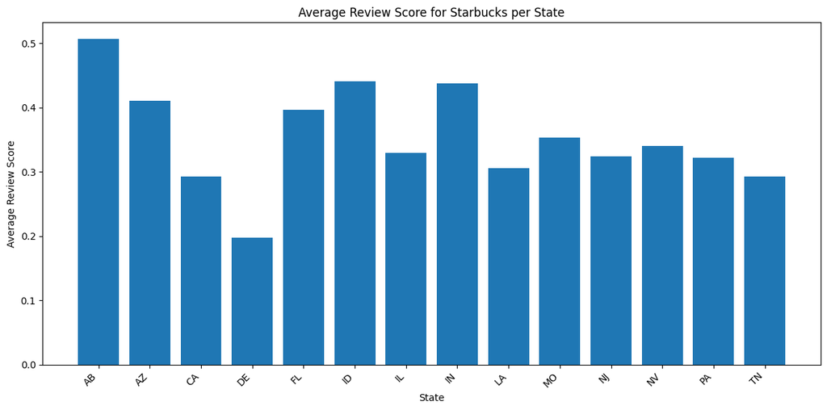

```python
import matplotlib.pyplot as plt

# Assuming starbucks_reviews DataFrame is already created as in the previous code

# 1. Plot the number of Starbucks locations per state
starbucks_by_state = starbucks_reviews['state'].value_counts()
plt.figure(figsize=(12, 6))
plt.bar(starbucks_by_state.index, starbucks_by_state.values)
plt.xlabel("State")
plt.ylabel("Number of Starbucks Locations")
plt.title("Number of Starbucks Locations per State")
plt.xticks(rotation=45, ha='right')  # Rotate x-axis labels for readability
plt.tight_layout() # Adjust layout to prevent labels from overlapping
plt.show()


# 2. Plot the average review score per state
# Extract compound sentiment scores
starbucks_reviews['compound_sentiment'] = starbucks_reviews['sentiment_scores'].apply(lambda x: x['compound'])

# Group by state and calculate the average compound sentiment
average_sentiment_by_state = starbucks_reviews.groupby('state')['compound_sentiment'].mean()

plt.figure(figsize=(12, 6))
plt.bar(average_sentiment_by_state.index, average_sentiment_by_state.values)
plt.xlabel("State")
plt.ylabel("Average Review Score")
plt.title("Average Review Score for Starbucks per State")
plt.xticks(rotation=45, ha='right') # Rotate x-axis labels for readability
plt.tight_layout() # Adjust layout to prevent labels from overlapping
plt.show()
```

## Data Evaluation

a. Our main questions are centered around Starbucks' customer experience performance (such as what the general sentiment is and how sentiment has changed over time); the review data we have is an excellent source of information that can answer these questions and provide us with valuable insights.  
b. We have a total of 21,739 reviews in our dataset, which is an appropriate sample size for our analysis.  
c. Two areas where bias may be a concern is the unbalanced ratio of positive to negative reviews and the number of reviews between states being unbalanced.  
d. The two biggest potential challenges of processing this data is the processing time some parts of the analysis will require (which we have partially alleviated by focusing on Starbucks) and finding specific and actionable solutions to insights with this data.

## Preliminary Data Exploration

```python
# Group by state and calculate the average review score and composite sentiment score
state_level_stats = starbucks_reviews.groupby('state')[['stars_x', 'compound_sentiment']].mean()

# Rename columns for clarity
state_level_stats = state_level_stats.rename(columns={'stars_x': 'average_review_score', 'compound_sentiment': 'average_sentiment_score'})

# Display the results
state_level_stats
```

| state | average_review_score | average_sentiment_score |
| --- | --- | --- |
| AB | 3.340909 | 0.506922 |
| AZ | 3.203582 | 0.410648 |
| CA | 2.956701 | 0.293088 |
| DE | 2.642229 | 0.197182 |
| FL | 3.178079 | 0.396388 |
| ID | 3.290503 | 0.440747 |
| IL | 3.018382 | 0.329050 |
| IN | 3.354867 | 0.437341 |
| LA | 2.892449 | 0.305801 |
| MO | 3.113739 | 0.353687 |
| NJ | 3.036386 | 0.323500 |
| NV | 2.953895 | 0.339840 |
| PA | 2.990375 | 0.322297 |
| TN | 2.867388 | 0.292960 |

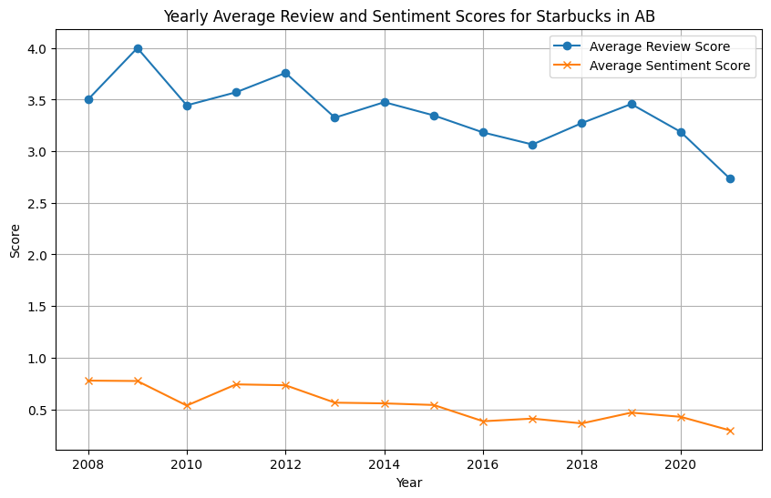

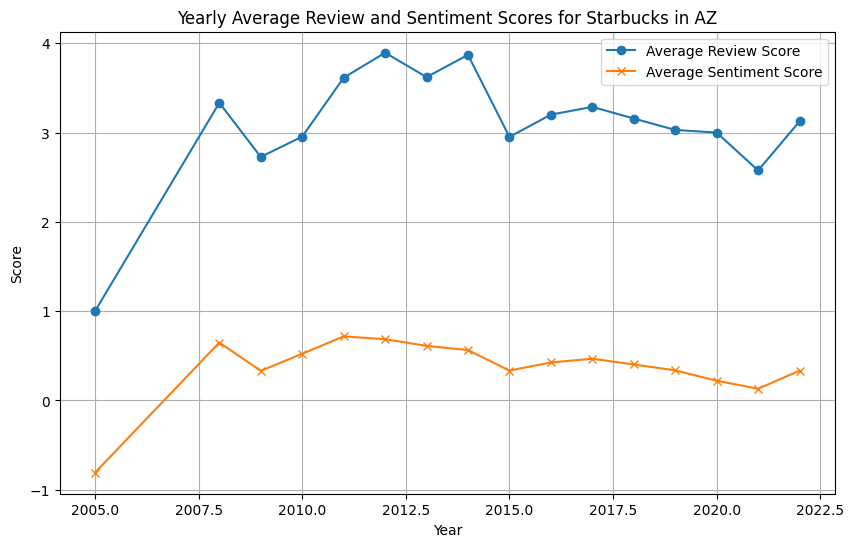

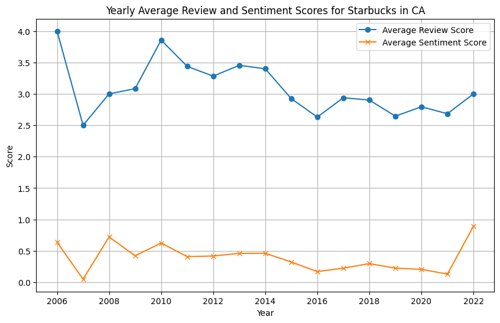

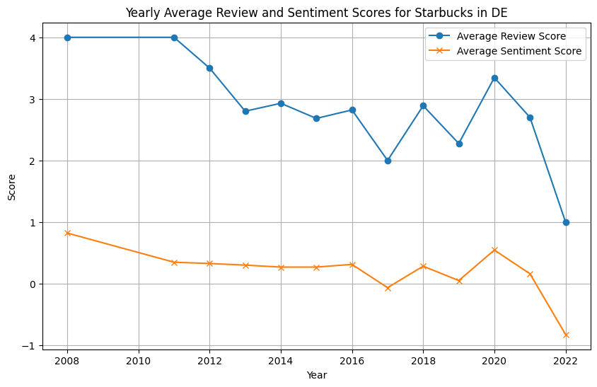

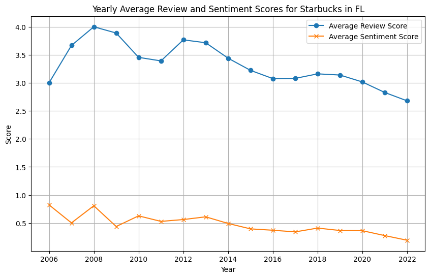

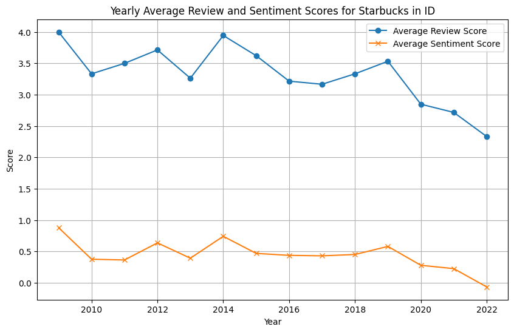

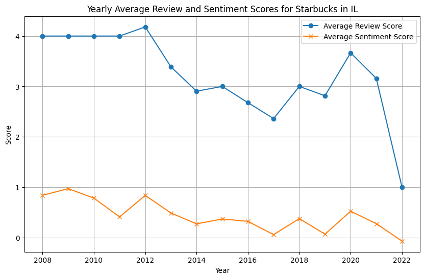

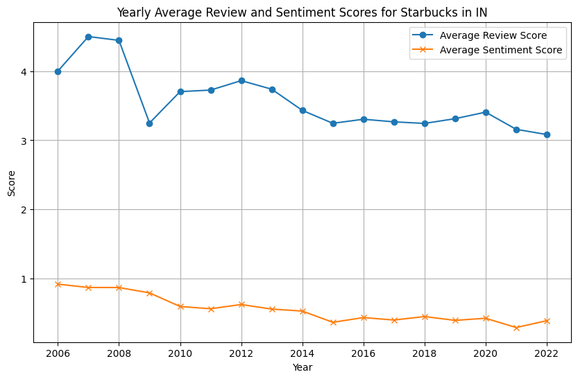

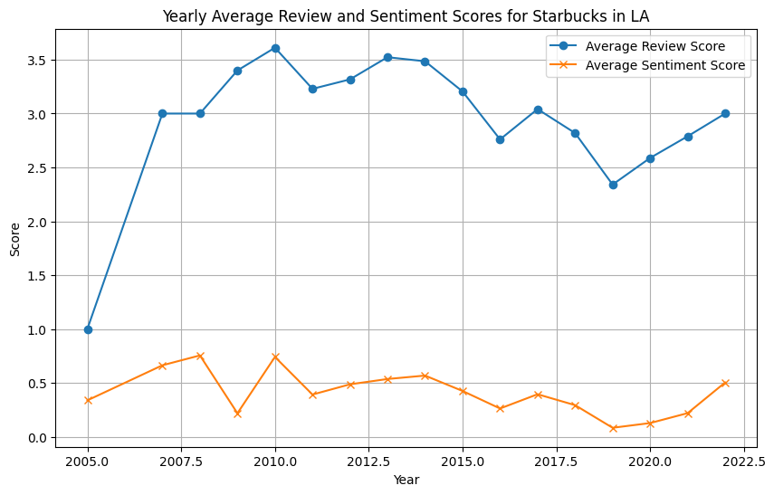

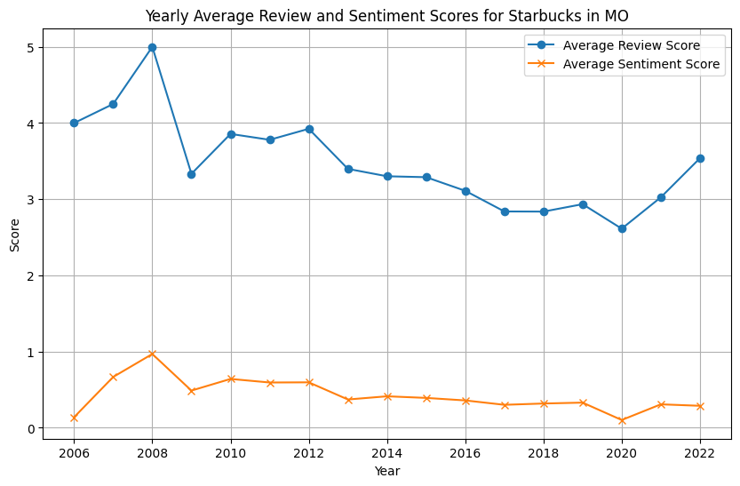

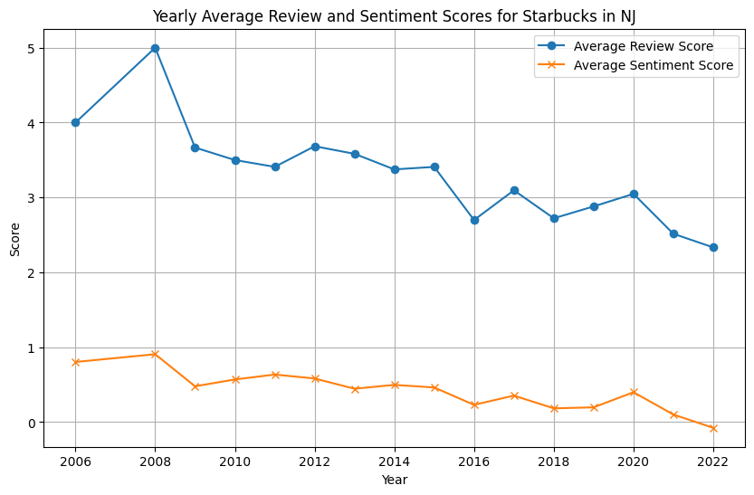

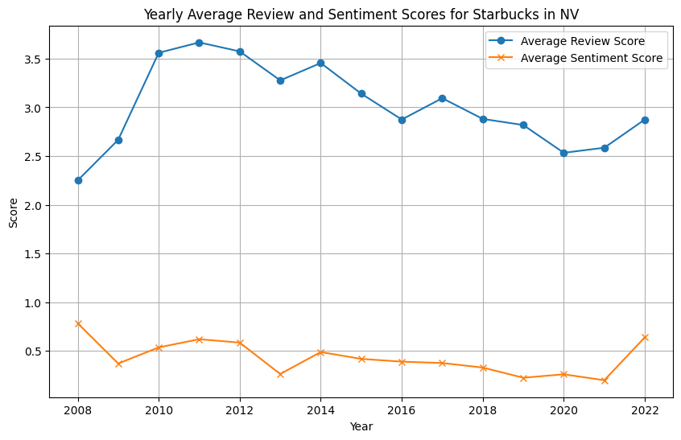

[2 more figures not shown]

```python
#Plot the average review and sentiment scores in each state by year

import matplotlib.pyplot as plt

# Assuming starbucks_reviews DataFrame is already loaded and processed as in the previous code

# Convert the 'date' column to datetime objects if not already done
starbucks_reviews['date'] = pd.to_datetime(starbucks_reviews['date'])

# Extract the year
starbucks_reviews['year'] = starbucks_reviews['date'].dt.year

# Group by state and year, then calculate the mean review and sentiment scores
yearly_state_stats = starbucks_reviews.groupby(['state', 'year'])[['stars_x', 'compound_sentiment']].mean().reset_index()

# Rename columns for clarity
yearly_state_stats = yearly_state_stats.rename(columns={'stars_x': 'average_review_score', 'compound_sentiment': 'average_sentiment_score'})

# Iterate through each state and create a plot
for state in yearly_state_stats['state'].unique():
    state_data = yearly_state_stats[yearly_state_stats['state'] == state]

    plt.figure(figsize=(10, 6))
    plt.plot(state_data['year'], state_data['average_review_score'], label='Average Review Score', marker='o')
    plt.plot(state_data['year'], state_data['average_sentiment_score'], label='Average Sentiment Score', marker='x')

    plt.xlabel('Year')
    plt.ylabel('Score')
    plt.title(f'Yearly Average Review and Sentiment Scores for Starbucks in {state}')
    plt.legend()
    plt.grid(True)
    plt.show()
```

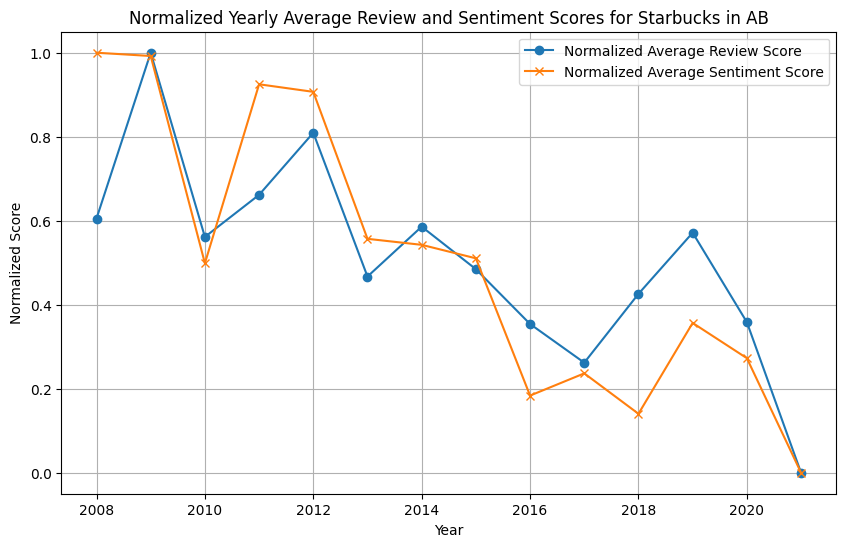

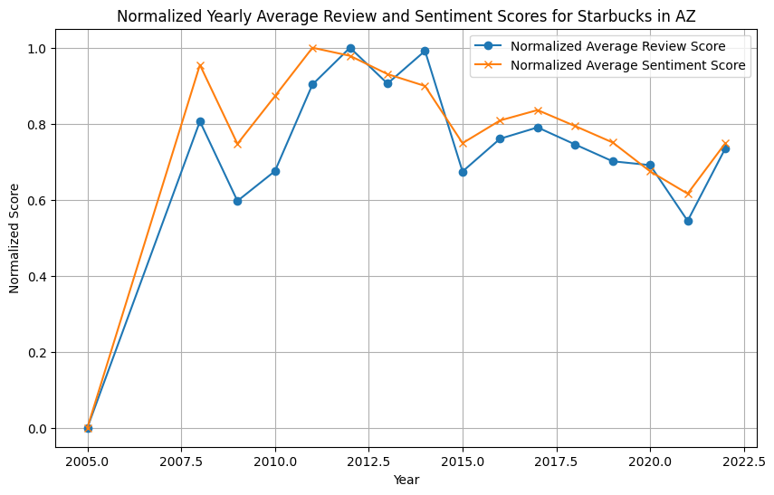

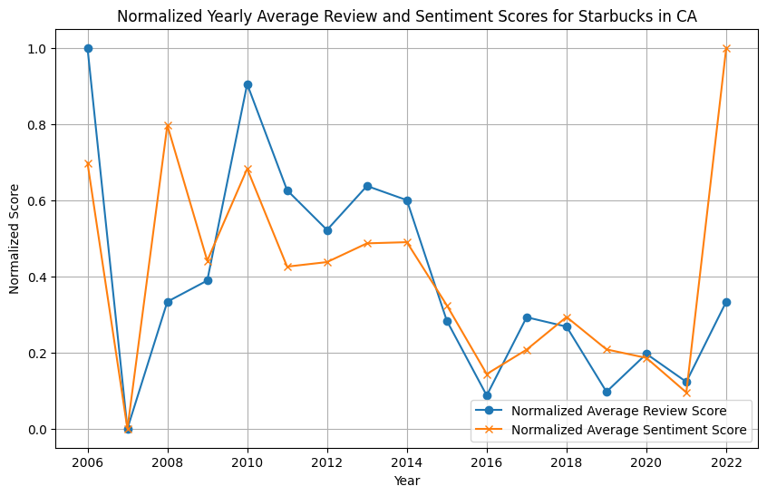

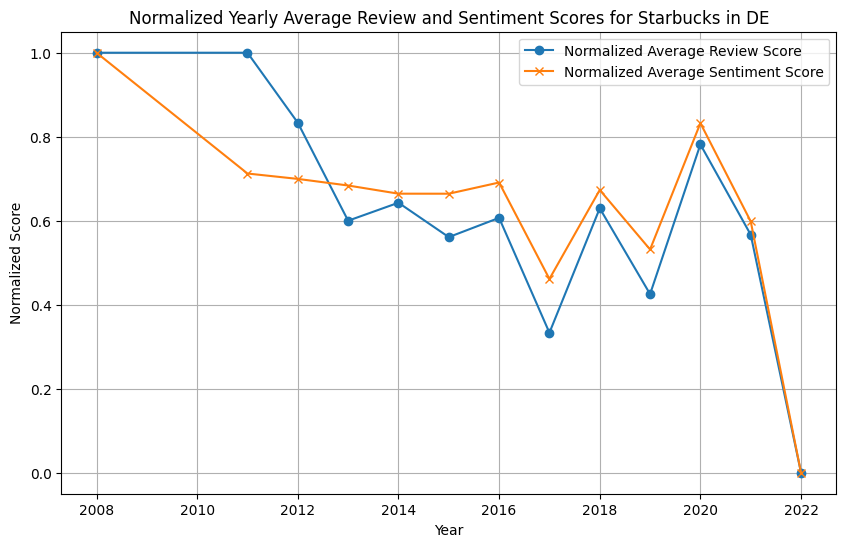

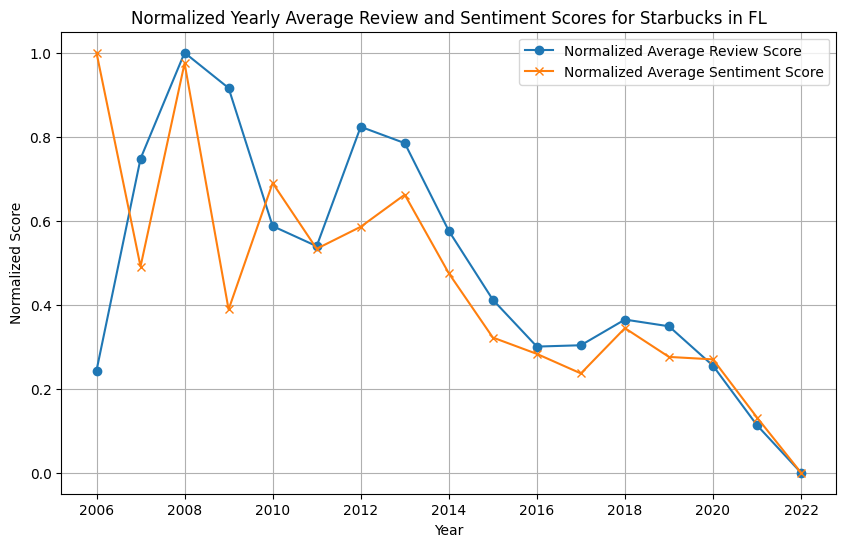

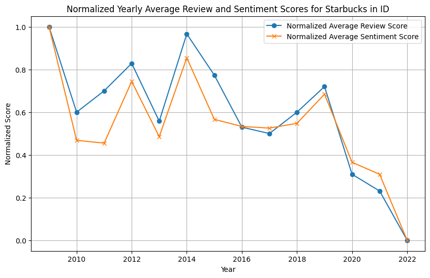

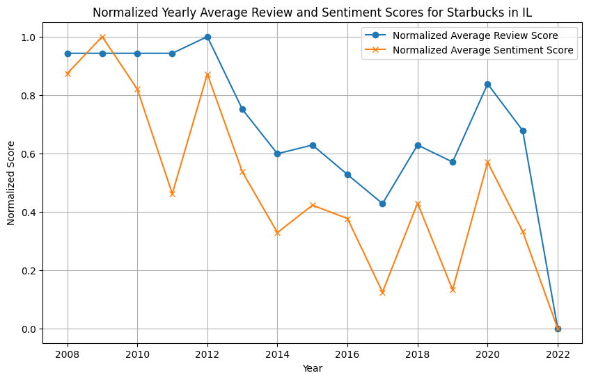

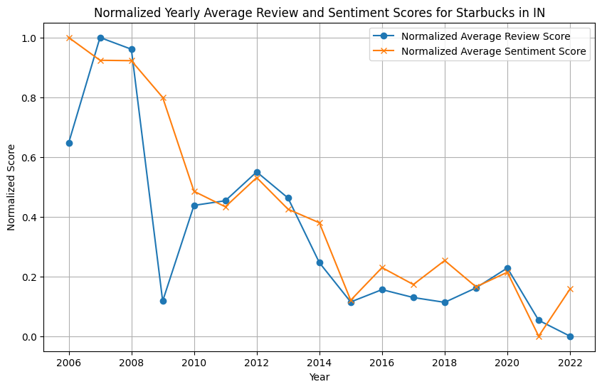

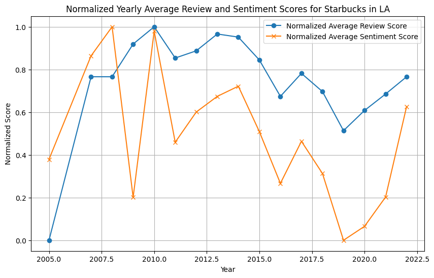

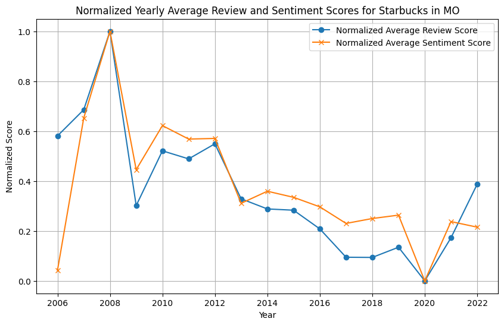

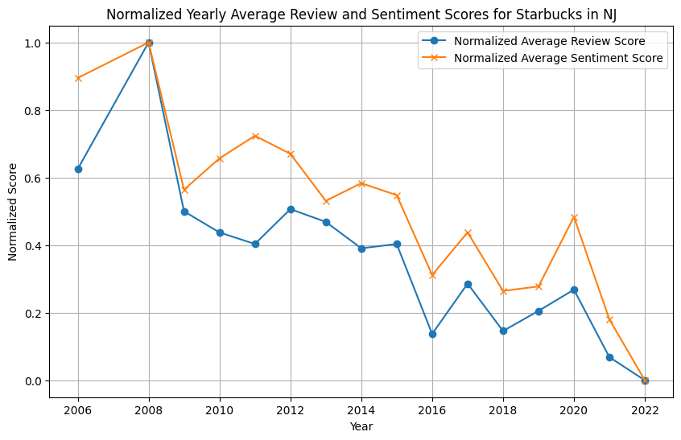

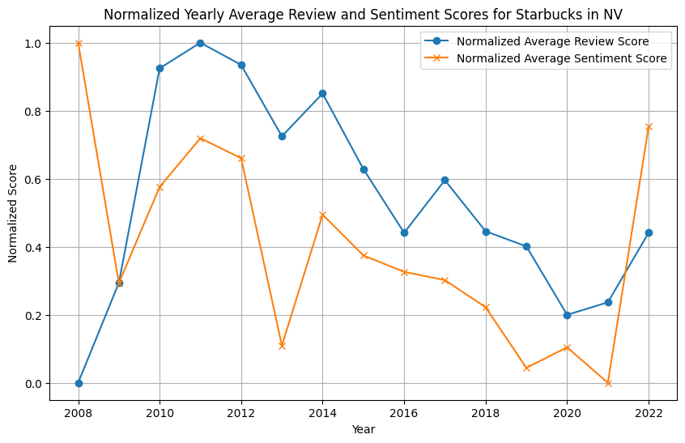

[2 more figures not shown]

```python
# Normalized average review and normalized sentiment scores in each state by year

import matplotlib.pyplot as plt

# Assuming yearly_state_stats DataFrame is already created as in the previous code

# Normalize the scores for each state
for state in yearly_state_stats['state'].unique():
    state_data = yearly_state_stats[yearly_state_stats['state'] == state].copy()  # Create a copy to avoid SettingWithCopyWarning

    # Normalize average_review_score
    state_data['normalized_average_review_score'] = (state_data['average_review_score'] - state_data['average_review_score'].min()) / (state_data['average_review_score'].max() - state_data['average_review_score'].min())

    # Normalize average_sentiment_score
    state_data['normalized_average_sentiment_score'] = (state_data['average_sentiment_score'] - state_data['average_sentiment_score'].min()) / (state_data['average_sentiment_score'].max() - state_data['average_sentiment_score'].min())


    plt.figure(figsize=(10, 6))
    plt.plot(state_data['year'], state_data['normalized_average_review_score'], label='Normalized Average Review Score', marker='o')
    plt.plot(state_data['year'], state_data['normalized_average_sentiment_score'], label='Normalized Average Sentiment Score', marker='x')

    plt.xlabel('Year')
    plt.ylabel('Normalized Score')
    plt.title(f'Normalized Yearly Average Review and Sentiment Scores for Starbucks in {state}')
    plt.legend()
    plt.grid(True)
    plt.show()
```

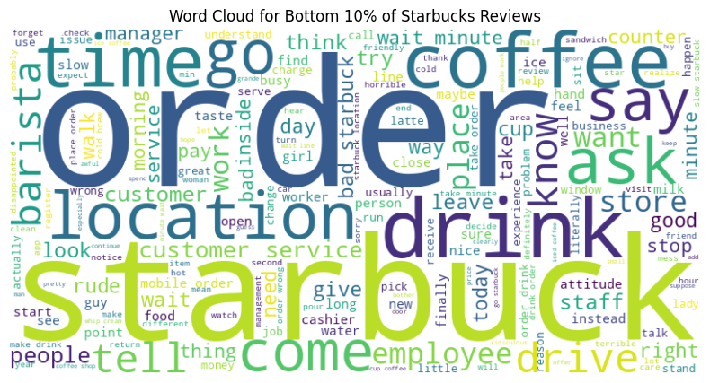

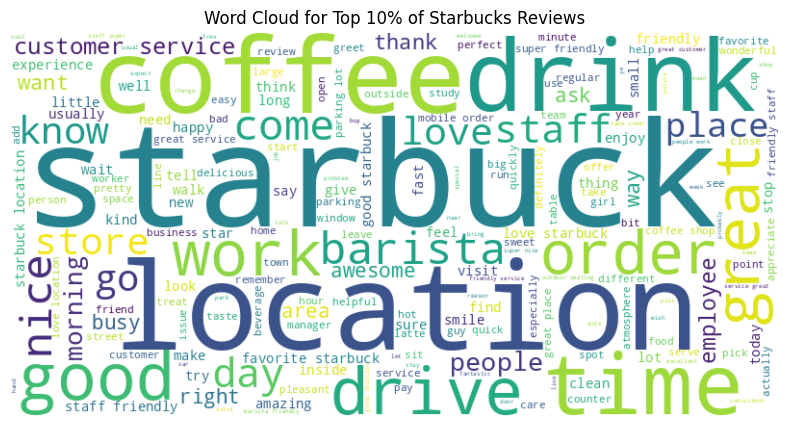

```python
# Word cloud for the top 10% of Starbucks reviews going by review score in the 'star_x' column as well as for the bottom 10% of reviews

!pip install wordcloud

from wordcloud import WordCloud

# Calculate the 10th and 90th percentiles of 'star_x'
percentile_10 = starbucks_reviews['stars_x'].quantile(0.10)
percentile_90 = starbucks_reviews['stars_x'].quantile(0.90)

# Filter reviews based on percentiles
bottom_10_reviews = starbucks_reviews[starbucks_reviews['stars_x'] <= percentile_10]
top_10_reviews = starbucks_reviews[starbucks_reviews['stars_x'] >= percentile_90]

# Function to generate and display word cloud
def generate_wordcloud(text, title):
    wordcloud = WordCloud(width=800, height=400, background_color='white').generate(' '.join(text))
    plt.figure(figsize=(10, 5))
    plt.imshow(wordcloud, interpolation='bilinear')
    plt.axis('off')
    plt.title(title)
    plt.show()


# Generate word clouds
generate_wordcloud(bottom_10_reviews['processed'], 'Word Cloud for Bottom 10% of Starbucks Reviews')
generate_wordcloud(top_10_reviews['processed'], 'Word Cloud for Top 10% of Starbucks Reviews')
```

## Proposed Solution

To do so, We will use methods such as language modeling to create aggregate summaries based on the good and bad reviews reviews in each state to compare more precisely identify Starbucks' strengths and weaknesses.

We also want to use machine learning to perform regression on the sentiment data to figure what features are important in determining sentiment and predicting future customer sentiment.